# Population Growth and CO<sub>2</sub> Emissions: A Worldwide Analysis

Data management, exploratory analysis, projection and correlation study

MUGISHA Robert | 20252MBI062

06 November 2026

# 1 Introduction

This report investigates the relationship between **population size** and **CO<sub>2</sub> emissions** across the countries of the world. Two open datasets are used: the *World Population Dataset* and the *CO2 Emission Around the World* dataset (both from Kaggle). The workflow below follows the assignment brief: * data management and cleaning * exploratory data analysis * creation of a new * projected-population variable * visualisation of population * emission trends * correlation / regression study linking population to emissions.

## 1.1 Task 4.1 — Loading the data

```r
pop_path <- "./data/world_population.csv"
co2_path <- "./data/CO2_emission.csv"

population_raw <- read_csv(pop_path, show_col_types = FALSE)
co2_raw <- read_csv(co2_path, show_col_types = FALSE)
```

## 1.2 Task 4.2 — Exploratory Data Analysis (World Population Dataset)

### 1.2.1 Variable names

```r
names(population_raw)
```

```
##  [1] "Rank"                        "CCA3"
##  [3] "Country/Territory"           "Capital"
##  [5] "Continent"                   "2022 Population"
##  [7] "2020 Population"             "2015 Population"
##  [9] "2010 Population"             "2000 Population"
## [11] "1990 Population"             "1980 Population"
## [13] "1970 Population"             "Area (km²)"
## [15] "Density (per km²)"           "Growth Rate"
## [17] "World Population Percentage"
```

### 1.2.2 First 5 rows

```r
head(population_raw, 5)
```

| Rank | CCA3 | Country/Territory | Capital | Continent | 2022 Population | 2020 Population | 2015 Population | 2010 Population | 2000 Population | 1990 Population | 1980 Population | 1970 Population | Area (km²) | Density (per km²) | Growth Rate | World Population Percentage |
| --- | --- | --- | --- | --- | --- | --- | --- | --- | --- | --- | --- | --- | --- | --- | --- | --- |
| 36 | AFG | Afghanistan | Kabul | Asia | 41128771 | 38972230 | 33753499 | 28189672 | 19542982 | 10694796 | 12486631 | 10752971 | 652230 | 63.0587 | 1.0257 | 0.52 |
| 138 | ALB | Albania | Tirana | Europe | 2842321 | 2866849 | 2882481 | 2913399 | 3182021 | 3295066 | 2941651 | 2324731 | 28748 | 98.8702 | 0.9957 | 0.04 |
| 34 | DZA | Algeria | Algiers | Africa | 44903225 | 43451666 | 39543154 | 35856344 | 30774621 | 25518074 | 18739378 | 13795915 | 2381741 | 18.8531 | 1.0164 | 0.56 |
| 213 | ASM | American Samoa | Pago Pago | Oceania | 44273 | 46189 | 51368 | 54849 | 58230 | 47818 | 32886 | 27075 | 199 | 222.4774 | 0.9831 | 0.00 |
| 203 | AND | Andorra | Andorra la Vella | Europe | 79824 | 77700 | 71746 | 71519 | 66097 | 53569 | 35611 | 19860 | 468 | 170.5641 | 1.0100 | 0.00 |

### 1.2.3 Last 10 rows

```r
tail(population_raw, 10)
```

| Rank | CCA3 | Country/Territory | Capital | Continent | 2022 Population | 2020 Population | 2015 Population | 2010 Population | 2000 Population | 1990 Population | 1980 Population | 1970 Population | Area (km²) | Density (per km²) | Growth Rate | World Population Percentage |
| --- | --- | --- | --- | --- | --- | --- | --- | --- | --- | --- | --- | --- | --- | --- | --- | --- |
| 43 | UZB | Uzbekistan | Tashkent | Asia | 34627652 | 33526656 | 30949417 | 28614227 | 24925554 | 20579100 | 15947129 | 12011361 | 447400 | 77.3975 | 1.0160 | 0.43 |
| 181 | VUT | Vanuatu | Port-Vila | Oceania | 326740 | 311685 | 276438 | 245453 | 192074 | 150882 | 118156 | 87019 | 12189 | 26.8061 | 1.0238 | 0.00 |
| 234 | VAT | Vatican City | Vatican City | Europe | 510 | 520 | 564 | 596 | 651 | 700 | 733 | 752 | 1 | 510.0000 | 0.9980 | 0.00 |
| 51 | VEN | Venezuela | Caracas | South America | 28301696 | 28490453 | 30529716 | 28715022 | 24427729 | 19750579 | 15210443 | 11355475 | 916445 | 30.8820 | 1.0036 | 0.35 |
| 16 | VNM | Vietnam | Hanoi | Asia | 98186856 | 96648685 | 92191398 | 87411012 | 79001142 | 66912613 | 52968270 | 41928849 | 331212 | 296.4472 | 1.0074 | 1.23 |
| 226 | WLF | Wallis and Futuna | Mata-Utu | Oceania | 11572 | 11655 | 12182 | 13142 | 14723 | 13454 | 11315 | 9377 | 142 | 81.4930 | 0.9953 | 0.00 |
| 172 | ESH | Western Sahara | El Aaiún | Africa | 575986 | 556048 | 491824 | 413296 | 270375 | 178529 | 116775 | 76371 | 266000 | 2.1654 | 1.0184 | 0.01 |
| 46 | YEM | Yemen | Sanaa | Asia | 33696614 | 32284046 | 28516545 | 24743946 | 18628700 | 13375121 | 9204938 | 6843607 | 527968 | 63.8232 | 1.0217 | 0.42 |
| 63 | ZMB | Zambia | Lusaka | Africa | 20017675 | 18927715 | 16248230 | 13792086 | 9891136 | 7686401 | 5720438 | 4281671 | 752612 | 26.5976 | 1.0280 | 0.25 |
| 74 | ZWE | Zimbabwe | Harare | Africa | 16320537 | 15669666 | 14154937 | 12839771 | 11834676 | 10113893 | 7049926 | 5202918 | 390757 | 41.7665 | 1.0204 | 0.20 |

### 1.2.4 Data types

```r
tibble(
  Variable  = names(population_raw),
  Data_type = map_chr(population_raw, ~ class(.x)[1])
) %>% kable(caption = "Variable names and their data types")
```

Variable names and their data types

| Variable | Data_type |
| --- | --- |
| Rank | numeric |
| CCA3 | character |
| Country/Territory | character |
| Capital | character |
| Continent | character |
| 2022 Population | numeric |
| 2020 Population | numeric |
| 2015 Population | numeric |
| 2010 Population | numeric |
| 2000 Population | numeric |
| 1990 Population | numeric |
| 1980 Population | numeric |
| 1970 Population | numeric |
| Area (km²) | numeric |
| Density (per km²) | numeric |
| Growth Rate | numeric |
| World Population Percentage | numeric |

### 1.2.5 Shape of the dataset

```r
dim(population_raw)
```

```
## [1] 234  17
```

```r
glue::glue("The dataset has {nrow(population_raw)} rows (countries/territories) ",
           "and {ncol(population_raw)} columns (variables).")
```

```
## The dataset has 234 rows (countries/territories) and 17 columns (variables).
```

### 1.2.6 Tidy column names

To make the downstream code robust and readable we standardise the column names with `janitor::clean_names()`.

```r
population <- population_raw %>% clean_names()
names(population)
```

```
##  [1] "rank"                        "cca3"
##  [3] "country_territory"           "capital"
##  [5] "continent"                   "x2022_population"
##  [7] "x2020_population"            "x2015_population"
##  [9] "x2010_population"            "x2000_population"
## [11] "x1990_population"            "x1980_population"
## [13] "x1970_population"            "area_km2"
## [15] "density_per_km2"             "growth_rate"
## [17] "world_population_percentage"
```

### 1.2.7 Drop duplicate rows

```r
n_before <- nrow(population)
population <- population %>% distinct()
n_after <- nrow(population)
glue::glue("Duplicate rows removed: {n_before - n_after}. ",
           "Rows remaining: {n_after}.")
```

```
## Duplicate rows removed: 0. Rows remaining: 234.
```

### 1.2.8 Missing values per column

```r
missing_tbl <- population %>%
  summarise(across(everything(), ~ sum(is.na(.x)))) %>%
  pivot_longer(everything(), names_to = "variable", values_to = "n_missing") %>%
  arrange(desc(n_missing))

missing_tbl %>% kable(caption = "Number of missing values in each column")
```

Number of missing values in each column

| variable | n_missing |
| --- | --- |
| rank | 0 |
| cca3 | 0 |
| country_territory | 0 |
| capital | 0 |
| continent | 0 |
| x2022_population | 0 |
| x2020_population | 0 |
| x2015_population | 0 |
| x2010_population | 0 |
| x2000_population | 0 |
| x1990_population | 0 |
| x1980_population | 0 |
| x1970_population | 0 |
| area_km2 | 0 |
| density_per_km2 | 0 |
| growth_rate | 0 |
| world_population_percentage | 0 |

### 1.2.9 Identify the quantitative variables

```r
# Numeric columns that describe the current state of each country
quant_vars <- population %>%
  select(where(is.numeric)) %>%
  names()
quant_vars
```

```
##  [1] "rank"                        "x2022_population"
##  [3] "x2020_population"            "x2015_population"
##  [5] "x2010_population"            "x2000_population"
##  [7] "x1990_population"            "x1980_population"
##  [9] "x1970_population"            "area_km2"
## [11] "density_per_km2"             "growth_rate"
## [13] "world_population_percentage"
```

### 1.2.10 Outlier check with box plots

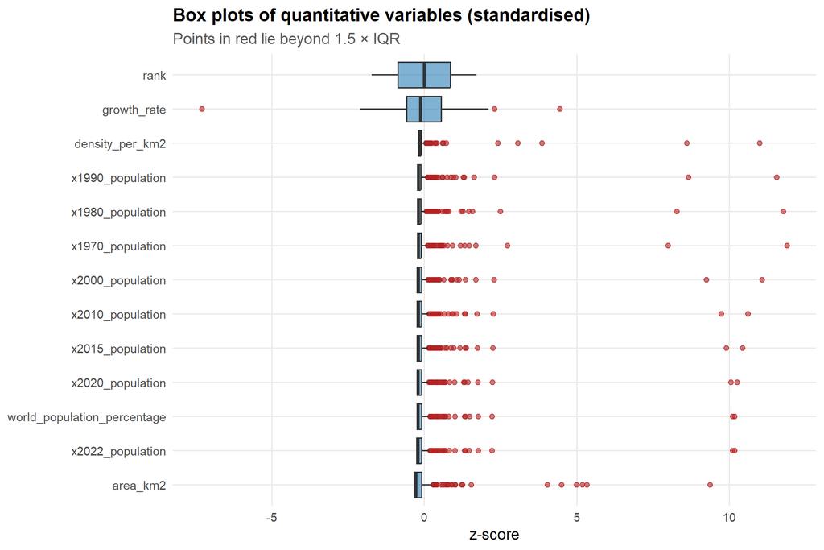

```r
pop_long <- population %>%
  select(all_of(quant_vars)) %>%
  mutate(across(everything(), ~ as.numeric(scale(.x)))) %>%   # z-scores
  pivot_longer(everything(), names_to = "variable", values_to = "z")

ggplot(pop_long, aes(x = reorder(variable, z, FUN = median, na.rm = TRUE), y = z)) +
  geom_boxplot(fill = pal_main, alpha = 0.6, outlier.colour = "firebrick",
               outlier.alpha = 0.6) +
  coord_flip() +
  labs(title = "Box plots of quantitative variables (standardised)",
       subtitle = "Points in red lie beyond 1.5 × IQR",
       x = NULL, y = "z-score")
```

### 1.2.11 Dealing with missing values and outliers

**Missing values.** Numeric columns are imputed with the **median**, which is robust to skew; any missing categorical label is set to `"Unknown"`.

```r
population <- population %>%
  mutate(across(where(is.numeric), ~ ifelse(is.na(.x), median(.x, na.rm = TRUE), .x))) %>%
  mutate(across(where(is.character), ~ ifelse(is.na(.x), "Unknown", .x)))

# confirm no missing values remain
sum(is.na(population))
```

```
## [1] 0
```

**Outliers.** For this dataset the extreme values in the *population* columns are **genuine** (China and India really are an order of magnitude larger than most countries), so they are retained for the ranking tasks. For the *rate-type* variables used later in the correlation study — `density`, `growth_rate` and `world_population_percentage` — we apply **IQR capping (winsorising)** so that a handful of extreme territories do not dominate the correlations. The capped copies are stored in new `*_capped` columns and the originals are left untouched.

```r
cap_iqr <- function(x) {
  q <- quantile(x, c(.25, .75), na.rm = TRUE)
  iqr <- diff(q)
  lo <- q[1] - 1.5 * iqr
  hi <- q[2] + 1.5 * iqr
  pmin(pmax(x, lo), hi)
}

rate_vars <- intersect(c("density_per_km2", "growth_rate",
                         "world_population_percentage"), names(population))

population <- population %>%
  mutate(across(all_of(rate_vars), cap_iqr, .names = "{.col}_capped"))

glue::glue("Winsorised (IQR-capped) copies created for: ",
           "{paste(rate_vars, collapse = ', ')}.")
```

```
## Winsorised (IQR-capped) copies created for: density_per_km2, growth_rate, world_population_percentage.
```

## 1.3 Task 4.3 — New variable: projected 2030 population

The exponential population-growth model is

$$N_t = P\,e^{rt},$$

where $P$ is the present population (end of **2022**), $r$ the growth rate, $t$ the number of years ahead, and $e \approx 2.71828$. We project to **2030**, so $t = 2030 - 2022 = 8$.

The raw `growth_rate` column is inspected first, because the dataset may store it either as an **annual factor** (values near `1.00`), as a **fraction** (e.g. `0.021`) or as a **percentage** (e.g. `2.1`). The code converts whichever form is present into a continuous rate $r$.

```r
# locate the 2022 population column
pop_2022_col <- names(population)[str_detect(names(population), "2022")][1]
med_gr <- median(population$growth_rate, na.rm = TRUE)

r_vec <- dplyr::case_when(
  med_gr > 0.5 & med_gr < 1.5 ~ population$growth_rate - 1,  # annual factor
  med_gr >= 1.5               ~ population$growth_rate / 100, # percentage
  TRUE                        ~ population$growth_rate        # already a fraction
)

glue::glue("Median raw growth_rate = {round(med_gr, 4)}  ->  ",
           "interpreted as {ifelse(med_gr > 0.5 & med_gr < 1.5, 'annual factor (r = rate - 1)', ifelse(med_gr >= 1.5, 'percentage (r = rate / 100)', 'fraction (r = rate)'))}.")
```

```
## Median raw growth_rate = 1.0079  ->  interpreted as annual factor (r = rate - 1).
```

```r
t_years <- 2030 - 2022

population <- population %>%
  mutate(
    r = r_vec,
    pop_2022 = .data[[pop_2022_col]],
    projected_2030 = round(pop_2022 * exp(r * t_years))
  )

population %>%
  select(country = matches("country"), continent,
         pop_2022, growth_rate, r, projected_2030) %>%
  arrange(desc(pop_2022)) %>%
  head(10) %>%
  kable(caption = "Projected 2030 population (top 10 countries by 2022 population)",
        format.args = list(big.mark = ","))
```

Projected 2030 population (top 10 countries by 2022 population)

| country | continent | pop_2022 | growth_rate | r | projected_2030 |
| --- | --- | --- | --- | --- | --- |
| China | Asia | 1,425,887,337 | 1.0000 | 0.0000 | 1,425,887,337 |
| India | Asia | 1,417,173,173 | 1.0068 | 0.0068 | 1,496,402,904 |
| United States | North America | 338,289,857 | 1.0038 | 0.0038 | 348,731,782 |
| Indonesia | Asia | 275,501,339 | 1.0064 | 0.0064 | 289,974,355 |
| Pakistan | Asia | 235,824,862 | 1.0191 | 0.0191 | 274,757,645 |
| Nigeria | Africa | 218,541,212 | 1.0241 | 0.0241 | 265,011,868 |
| Brazil | South America | 215,313,498 | 1.0046 | 0.0046 | 223,384,633 |
| Bangladesh | Asia | 171,186,372 | 1.0108 | 0.0108 | 186,634,630 |
| Russia | Europe | 144,713,314 | 0.9973 | -0.0027 | 141,621,023 |
| Mexico | North America | 127,504,125 | 1.0063 | 0.0063 | 134,095,029 |

## 1.4 Task 4.4 — Top-10 most populous countries: values and plots

### 1.4.1 4.4.1 Top 10 by 2022 population

```r
country_col <- names(population)[str_detect(names(population), "country_territory")][1]

top10 <- population %>%
  arrange(desc(pop_2022)) %>%
  slice(1:10) %>%
  mutate(country = .data[[country_col]])

top10_names <- top10$country
```

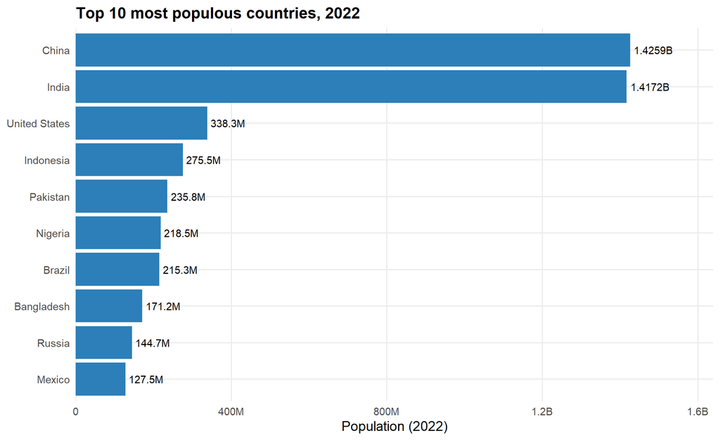

```r
ggplot(top10, aes(x = reorder(country, pop_2022), y = pop_2022)) +
  geom_col(fill = pal_main) +
  geom_text(aes(label = scales::label_number(scale_cut = cut_short_scale())(pop_2022)),
            hjust = -0.1, size = 3.3) +
  coord_flip() +
  scale_y_continuous(labels = label_number(scale_cut = cut_short_scale()),
                     expand = expansion(mult = c(0, 0.15))) +
  labs(title = "Top 10 most populous countries, 2022",
       x = NULL, y = "Population (2022)")
```

### 1.4.2 4.4.2 Population trend 1990–2022 for the top 10

The population dataset reports census snapshots (1990, 2000, 2010, 2015, 2020, 2022). We reshape those columns to long format and plot the trend.

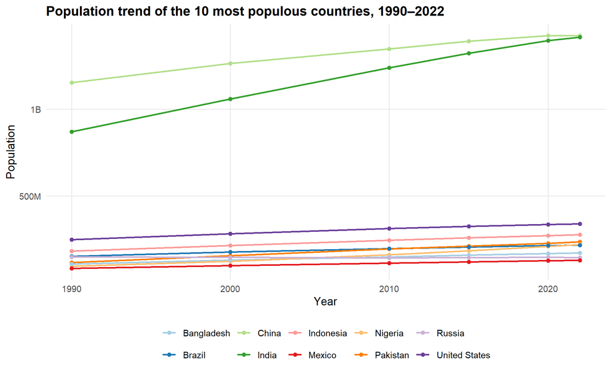

```r
year_cols <- names(population)[str_detect(names(population), "^x(19|20)\\d{2}_population$")]

trend <- top10 %>%
  select(country, all_of(year_cols)) %>%
  pivot_longer(all_of(year_cols), names_to = "year", values_to = "pop") %>%
  mutate(year = as.integer(str_extract(year, "\\d{4}"))) %>%
  filter(year >= 1990)

ggplot(trend, aes(year, pop, colour = country)) +
  geom_line(linewidth = 0.9) +
  geom_point(size = 1.6) +
  scale_y_continuous(labels = label_number(scale_cut = cut_short_scale())) +
  scale_colour_brewer(palette = "Paired") +
  labs(title = "Population trend of the 10 most populous countries, 1990–2022",
       x = "Year", y = "Population", colour = NULL)
```

### 1.4.3 4.4.3 CO<sub>2</sub> emission trend 1990–2019 for the same countries

```r
co2 <- co2_raw %>% clean_names()
co2_year_cols <- names(co2)[str_detect(names(co2), "^x(19|20)\\d{2}")]
co2_country_col <- names(co2)[str_detect(names(co2), "country_name|country$")][1]

co2_long <- co2 %>%
  rename(country = all_of(co2_country_col)) %>%
  select(country, all_of(co2_year_cols)) %>%
  pivot_longer(all_of(co2_year_cols), names_to = "year", values_to = "co2_pc") %>%
  mutate(year = as.integer(str_extract(year, "\\d{4}"))) %>%
  group_by(country, year) %>%
  summarise(co2_pc = mean(co2_pc, na.rm = TRUE), .groups = "drop") %>%
  mutate(co2_pc = ifelse(is.nan(co2_pc), NA_real_, co2_pc))

# match the top-10 country names (handles minor naming differences)
name_fix <- c("United States" = "United States",
              "Russia" = "Russian Federation",
              "Egypt" = "Egypt, Arab Rep.")
top10_co2_names <- recode(top10_names, !!!name_fix)

co2_top10 <- co2_long %>%
  filter(country %in% c(top10_names, top10_co2_names),
         year >= 1990, year <= 2019)
```

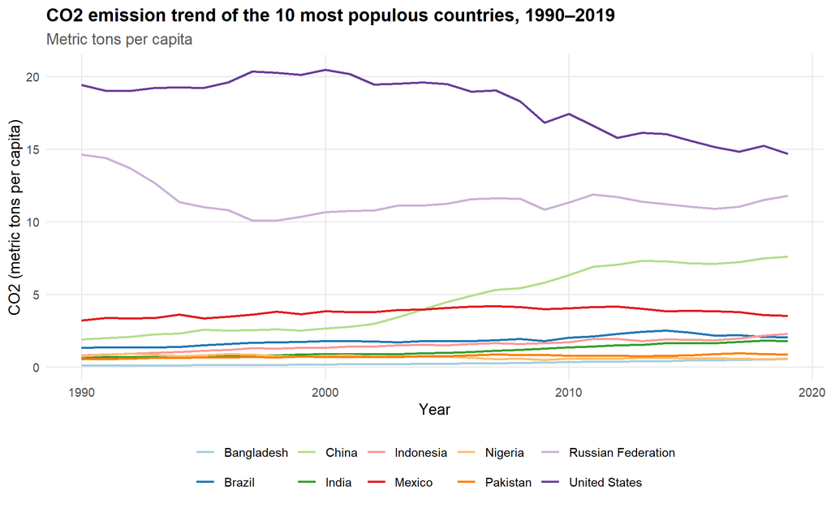

```r
ggplot(co2_top10, aes(year, co2_pc, colour = country)) +
  geom_line(linewidth = 0.9) +
  scale_colour_brewer(palette = "Paired") +
  labs(title = "CO2 emission trend of the 10 most populous countries, 1990–2019",
       subtitle = "Metric tons per capita",
       x = "Year", y = "CO2 (metric tons per capita)", colour = NULL)
```

## 1.5 Task 4.5 — Correlation analysis

### 1.5.1 4.5.1 Correlations within the population dataset

Correlations between **Area**, **Density**, **Growth rate** and **World population percentage** (using the IQR-capped rate variables), shown both as a numeric matrix and as a heatmap.

```r
area_col <- names(population)[str_detect(names(population), "area")][1]

corr_df <- population %>%
  transmute(
    Area        = .data[[area_col]],
    Density     = density_per_km2_capped,
    Growth_rate = growth_rate_capped,
    World_pct   = world_population_percentage_capped
  )

corr_mat <- cor(corr_df, use = "complete.obs")
round(corr_mat, 3) %>% kable(caption = "Correlation matrix (population variables)")
```

Correlation matrix (population variables)

|  | Area | Density | Growth_rate | World_pct |
| --- | --- | --- | --- | --- |
| Area | 1.000 | -0.210 | -0.013 | 0.441 |
| Density | -0.210 | 1.000 | -0.198 | -0.127 |
| Growth_rate | -0.013 | -0.198 | 1.000 | 0.183 |
| World_pct | 0.441 | -0.127 | 0.183 | 1.000 |

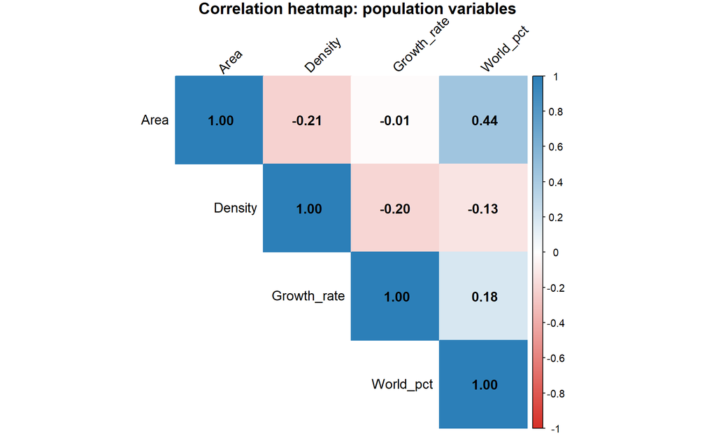

```r
corrplot(corr_mat, method = "color", type = "upper",
         addCoef.col = "black", tl.col = "black", tl.srt = 45,
         col = colorRampPalette(c("#D73027", "white", "#2C7FB8"))(200),
         mar = c(0, 0, 1, 0), title = "Correlation heatmap: population variables")
```

### 1.5.2 4.5.2 Population vs CO<sub>2</sub> emissions (merged data)

The two datasets are merged on country name; we then keep **2022 population** and **2019 CO<sub>2</sub> emissions** and study the relationship with a scatter plot, correlation coefficients and a simple linear regression.

```r
co2_2019 <- co2_long %>%
  filter(year == 2019) %>%
  select(country, co2_2019 = co2_pc)

pop_small <- population %>%
  transmute(country = .data[[country_col]],
            continent,
            pop_2022,
            projected_2030)

# normalise a few well-known name mismatches before joining
norm_name <- function(x) {
  x %>%
    str_replace_all("United States of America", "United States") %>%
    str_replace_all("Russian Federation", "Russia") %>%
    str_replace_all("Egypt, Arab Rep.", "Egypt") %>%
    str_replace_all("Iran, Islamic Rep.", "Iran") %>%
    str_replace_all("Korea, Rep.", "South Korea") %>%
    str_trim()
}

merged <- pop_small %>%
  mutate(country = norm_name(country)) %>%
  inner_join(co2_2019 %>% mutate(country = norm_name(country)), by = "country") %>%
  filter(!is.na(co2_2019), !is.na(pop_2022))

glue::glue("Countries successfully matched across both datasets: {nrow(merged)}")
```

```
## Countries successfully matched across both datasets: 172
```

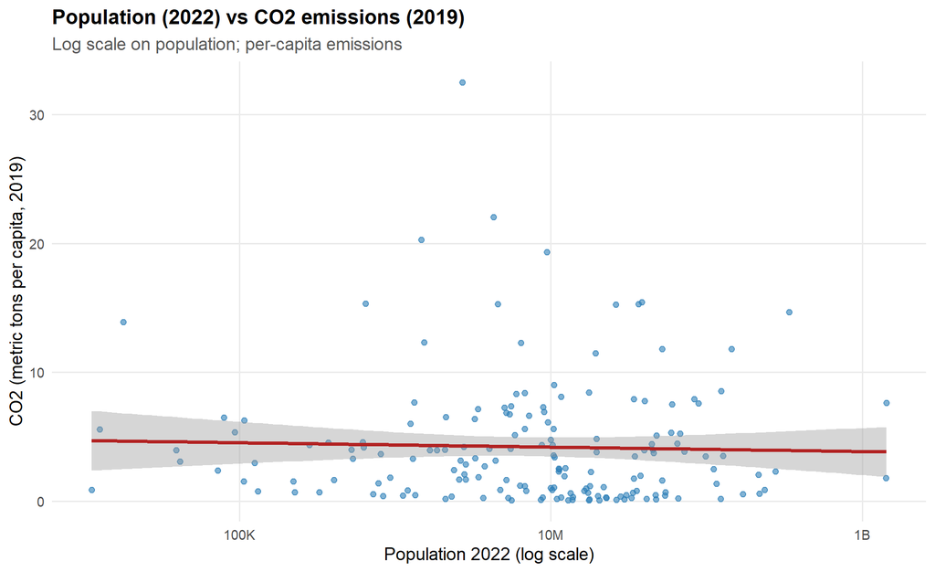

```r
ggplot(merged, aes(pop_2022, co2_2019)) +
  geom_point(alpha = 0.6, colour = pal_main) +
  geom_smooth(method = "lm", se = TRUE, colour = "firebrick") +
  scale_x_log10(labels = label_number(scale_cut = cut_short_scale())) +
  labs(title = "Population (2022) vs CO2 emissions (2019)",
       subtitle = "Log scale on population; per-capita emissions",
       x = "Population 2022 (log scale)",
       y = "CO2 (metric tons per capita, 2019)")
```

```r
pear <- cor(merged$pop_2022, merged$co2_2019, method = "pearson")
spear <- cor(merged$pop_2022, merged$co2_2019, method = "spearman")
pear_log <- cor(log10(merged$pop_2022), merged$co2_2019, method = "pearson")

tibble(
  Measure = c("Pearson (raw)", "Spearman (rank)", "Pearson (log population)"),
  Value   = round(c(pear, spear, pear_log), 3)
) %>% kable(caption = "Association between 2022 population and 2019 CO2 per capita")
```

Association between 2022 population and 2019 CO2 per capita

| Measure | Value |
| --- | --- |
| Pearson (raw) | 0.015 |
| Spearman (rank) | -0.088 |
| Pearson (log population) | -0.033 |

```r
lm_fit <- lm(co2_2019 ~ log10(pop_2022), data = merged)
summary(lm_fit)
```

```
##
## Call:
## lm(formula = co2_2019 ~ log10(pop_2022), data = merged)
##
## Residuals:
##    Min     1Q Median     3Q    Max
## -4.184 -3.396 -1.484  1.469 28.186
##
## Coefficients:
##                 Estimate Std. Error t value Pr(>|t|)
## (Intercept)       5.3858     2.7417   1.964   0.0511 .
## log10(pop_2022)  -0.1706     0.3962  -0.431   0.6672
## ---
## Signif. codes:  0 '***' 0.001 '**' 0.01 '*' 0.05 '.' 0.1 ' ' 1
##
## Residual standard error: 4.823 on 170 degrees of freedom
## Multiple R-squared:  0.00109,    Adjusted R-squared:  -0.004786
## F-statistic: 0.1855 on 1 and 170 DF,  p-value: 0.6672
```

## 1.6 Task 4.6 — Comparing CO<sub>2</sub> emissions across continents

Using the merged data we sum the **2019 per-capita CO<sub>2</sub> emissions** within each continent and compare them graphically.

```r
cont_co2 <- merged %>%
  group_by(continent) %>%
  summarise(total_co2_2019 = sum(co2_2019, na.rm = TRUE),
            n_countries = n(), .groups = "drop") %>%
  arrange(desc(total_co2_2019))

cont_co2 %>% kable(caption = "Total 2019 CO2 (metric tons per capita) by continent",
                   digits = 2)
```

Total 2019 CO2 (metric tons per capita) by continent

| continent | total_co2_2019 | n_countries |
| --- | --- | --- |
| Asia | 261.42 | 39 |
| Europe | 240.97 | 41 |
| North America | 79.57 | 19 |
| Africa | 60.50 | 49 |
| Oceania | 53.20 | 13 |
| South America | 29.42 | 11 |

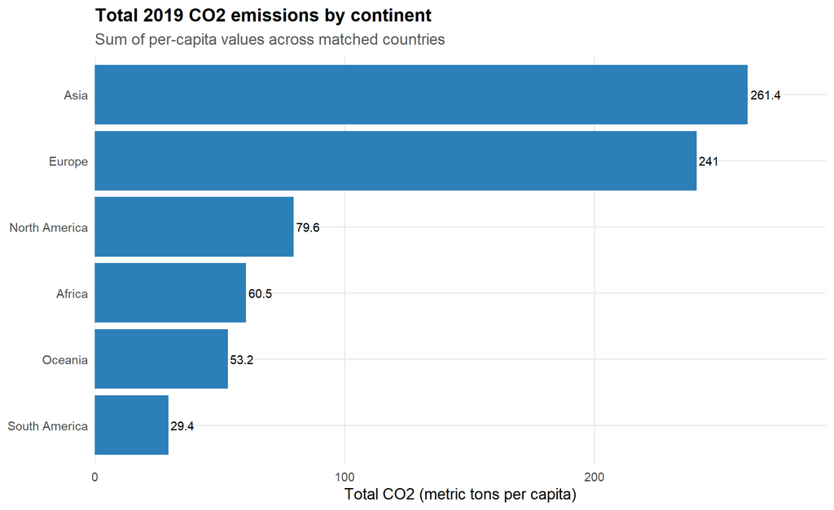

```r
ggplot(cont_co2, aes(x = reorder(continent, total_co2_2019), y = total_co2_2019)) +
  geom_col(fill = pal_main) +
  geom_text(aes(label = round(total_co2_2019, 1)), hjust = -0.1, size = 3.3) +
  coord_flip() +
  scale_y_continuous(expand = expansion(mult = c(0, 0.12))) +
  labs(title = "Total 2019 CO2 emissions by continent",
       subtitle = "Sum of per-capita values across matched countries",
       x = NULL, y = "Total CO2 (metric tons per capita)")
```

**Answers to the questions (computed from the data):**

1. **Highest 2019 CO2 emission:** Asia (total 261.42 metric tons per capita).
2. **Third-ranked continent:** North America, with a total of 79.57 metric tons per capita.
3. **Lowest-ranked continent:** South America, with a total of 29.42 metric tons per capita.

## 1.7 Conclusion

The analysis cleaned and prepared the World Population Dataset, projected each country’s population to 2030 with the exponential growth model, identified and visualised the ten most populous countries and their population and CO<sub>2</sub> trends, and quantified the link between population and per-capita emissions through correlation and regression. The continent comparison summarises where per-capita emissions concentrate. Full narrative discussion, limitations and recommendations are provided in the accompanying LaTeX report.